# Choosing a space occupancy metric

Thomas Guillerme

```r
library(dispRity)
library(knitr)
```

This script illustrates a potential pipeline of how to choose a correct space occupancy metric (*aka* functional diversity, dissimilarity, disparity metric) to answer a biological question. Our question here could be whether the functional diversity of Hawaiian native birds decreased more in the last 500 years than ever before? I.e. does the loss of species in the last 500 years constitute a greater decrease in trait space occupancy compared to the loss of all species recorded between 125,000 years ago and 500 years ago.

> Note that the exercise in this vignette can be done using the [`moms`](https://tguillerme.shinyapps.io/moms/) graphical user interface (with the associate manual [here](https://raw.githack.com/TGuillerme/moms/master/inst/moms_vignette.html)).

# The data

```r
## global trait space
empirical_traitspace <- read.csv('../Data/Raw/trait-space-5d-prehistoric-community.csv', row.names = 1)

## Species lists
historic_species <- rownames(read.csv('../Data/Raw/historic-species-list-minus-a-flammeus.csv', row.names = 1))
extant_species <- rownames(read.csv('../Data/Raw/present-species-list-minus-a-flammeus.csv', row.names = 1))

## Traitspace groups
extant_group <- rownames(empirical_traitspace) %in% extant_species ## 37 species present
historic_group <- rownames(empirical_traitspace) %in% historic_species ## 63 species present
groups <- list("extant" = extant_group, "historic" = historic_group)

## Creating a dispRity object containing all the groups
custom_groups <- lapply(groups, which)
custom_groups$all <- 1:nrow(empirical_traitspace)
grouped_space <- custom.subsets(empirical_traitspace, group = custom_groups)
```

## Visualising the data

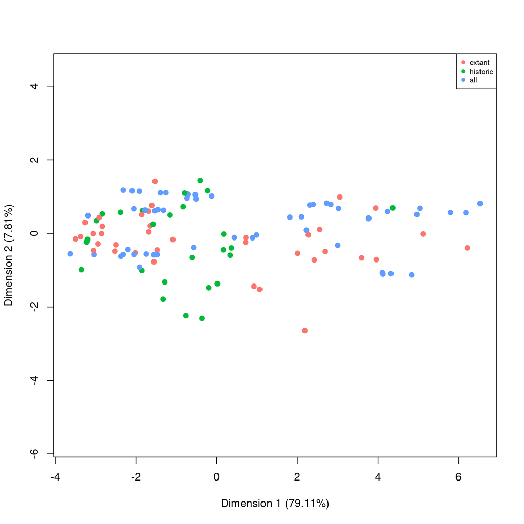

```r
## Visualising the group
plot(grouped_space)
```

Note here that the groups are subsets of each other so the species that are in the group `"extant"` (red) are also in the group `"historic"` (green) and `"all"` (blue). From visualising the data we can first see that both PC are a fair representation of the data (around 85% of the data). In other words, some things might happen on the other dimensions here (e.g. all the elements of one group might be weirdly distributed on some other PC axes) but that can only affect 15% of the data.

# Choosing a space occupancy metric

Once we have set up the data as a `dispRity` object, we can choose a space occupancy metric to reflect changes in the dataset. We can do that using already implemented metrics in `dispRity` (see `?dispRity.metric`) or by making our own metrics (see details below). The objective here will be to have a metric that reflects changes of interest. Again, the question being: “the functional diversity of Hawaiian endemic birds decreased more in the last 500 years than ever before?”; we can posit that changes in functional diversity should be approximated by changes in trait space size. The bigger the trait space, the more functional diversity.

> Note that this assumption should not be generalised. It is just what we posit for this dataset and this specific question.

## A simple case: the convex hull volume

We can start with a simple and rather intuitive measurement of trait space size: the volume of the convex hull of each group, that is volume of the smallest non-regular polygon that contains all points of each groups.

```r
## Measuring the convhull volume
convhull_volume <- dispRity(grouped_space,
                            metric = convhull.volume)
```

We can then summarise this in a table:

```r
## Printing the table
summary(convhull_volume)
```

| subsets | n | obs |
| --- | --- | --- |
| extant | 37 | 25.44 |
| historic | 63 | 60.84 |
| all | 118 | 85.41 |

## Checking sample size

However, we could note here that this change in volume is also closely linked to the change in the number of species, at least qualitatively (loosing 46.61% of species for the historic data and 68.64% for the extant data). This might not be a problem *per se* but in our case we are interested in the loss of function diversity not just the number of species. So we have to first check whether the changes of functional diversity are potentially de-coupled with changes in number of species. One way to do that is by rarefying the data, i.e. resampling each subset so they contain the same number of species. We can do that easily in `dispRity` using the `boot.matrix` function:

```r
## Measuring the convhull volume on the rarefied subsets (to 37 elements)
rarefied_conv_vol <- dispRity(boot.matrix(grouped_space, rarefaction = 37),
                              metric = convhull.volume)
```

```r
## Printing the table
summary(rarefied_conv_vol)
```

| subsets | n | obs | bs.median | 2.5% | 25% | 75% | 97.5% |
| --- | --- | --- | --- | --- | --- | --- | --- |
| extant | 37 | 25.44 | 11.90 | 5.26 | 9.00 | 15.46 | 20.68 |
| historic | 63 | 60.84 | 31.17 | 16.39 | 25.61 | 39.47 | 49.18 |
| historic | 37 | NA | 18.73 | 6.74 | 14.42 | 25.22 | 41.05 |
| all | 118 | 85.41 | 53.72 | 33.53 | 46.49 | 61.13 | 73.80 |
| all | 37 | NA | 16.00 | 5.47 | 12.62 | 20.48 | 32.36 |

Or plotting it:

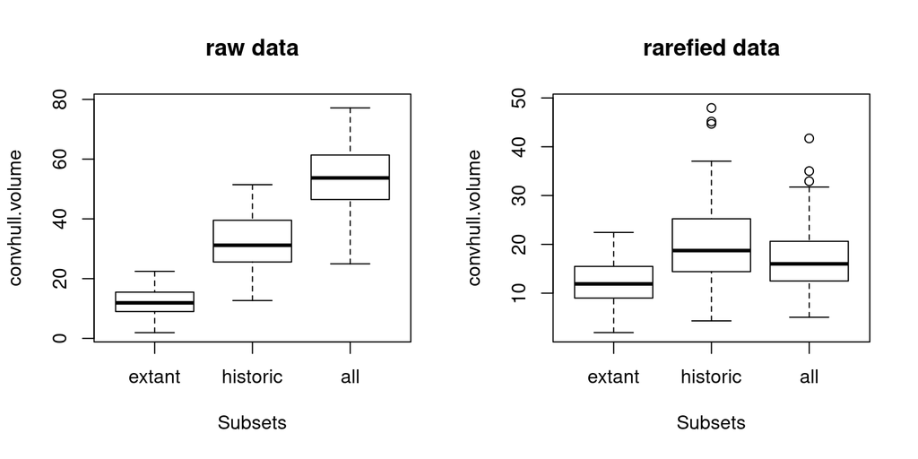

```r
par(mfrow = c(1, 2))
plot(rarefied_conv_vol, main = "raw data")
plot(rarefied_conv_vol, rarefaction = 37, main = "rarefied data")
```

Note that now the differences are not that clear. This might suggest that there is something with specific outliers in our dataset or that the metric is actually more capturing changes in the number of elements in the trait space rather than directly the trait space occupancy (*sensu* functional diversity).

## Checking the ability of the convex hull volume to capture changes in size

To check that, we can actually run some simulations to see whether the metric can actual capture changes in trait space size! We can do that using the `dispRity::test.metric` function from that uses the same pipeline used in (“Preprint” 2024) and Guillerme et al. (2020).

```r
## Testing the convex hull volume metric
convvol_test <- test.metric(grouped_space, metric = convhull.volume, shifts = c("random", "size"), replicates = 10)
```

```r
summary(convvol_test)
```

|  | 10% | 20% | 30% | 40% | 50% | 60% | 70% | 80% | 90% | 100% | slope | p_value | R^2(adj) |
| --- | --- | --- | --- | --- | --- | --- | --- | --- | --- | --- | --- | --- | --- |
| random | 1.15 | 12.55 | 18.09 | 28.54 | 33.06 | 48.24 | 48.99 | 69.23 | 78.18 | 85.41 | 0.9369765 | 0 | 0.9213137 |
| size.increase | 0.06 | 0.42 | 2.16 | 4.51 | 7.26 | 12.95 | 22.15 | 29.37 | 68.93 | 85.41 | 0.8741185 | 0 | 0.7659144 |
| size.hollowness | 0.09 | 16.38 | 28.49 | 49.91 | 57.38 | 62.04 | 71.86 | 81.88 | 85.08 | 85.41 | 0.9613572 | 0 | 0.9391030 |

The visualisation of the results:

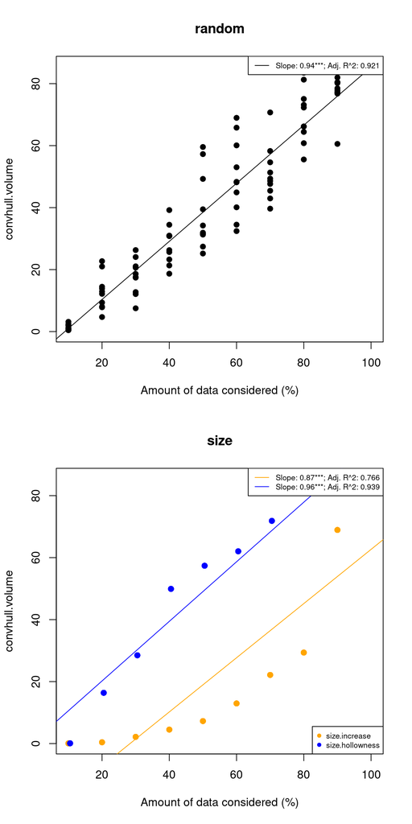

```r
plot(convvol_test)
```

Here we can clearly see that no matter which trait reduction we applied, we would always see a change of the convex hull volume linked to the change in the number of elements: we can see that the slope are very similar whether we randomly remove elements (black), remove elements from elements on the edge of the distribution (orange) or remove elements from the inside of the distribution (blue).

This should lead us to conclude that, even though the metric results make sense, they only do here because they are linked to the changes in the number of elements and we can never be sure whether it captures changes in trait space size (i.e. or proxy for functional diversity) or the number of elements (species richness).

> Note that this conclusion here is not a generalisation about this trait space or this metric. It is only valid for this specific trait space, this specific metric and this specific interpretation of function diversity.

# Testing different metrics

Unfortunately there is no one-size fit all recipe on how to find the correct metric for the dataset and question of interest. However, using tools like [`moms`](https://tguillerme.shinyapps.io/moms/) or `dispRity` we can test several ones and see which one fits our needs the best. Here is a series of them:

## The average spanning tree length

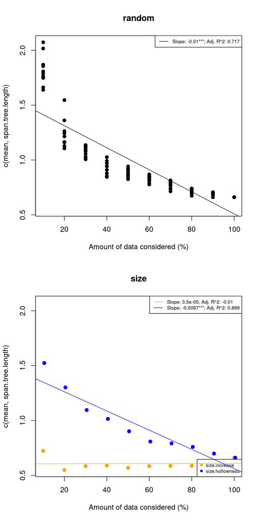

```r
plot(test.metric(grouped_space, metric = c(mean, span.tree.length), shifts = c("random", "size"), replicates = 10))
```

This metric is also not suitable as it seems inversely correlated to the sample size. Furthermore, it also seem to not pick changes in size (orange) but rather in hollowness (blue).

## The ratio of deviation from the centroid (functional diversity *sensu* Villéger, Mason, and Mouillot (2008))

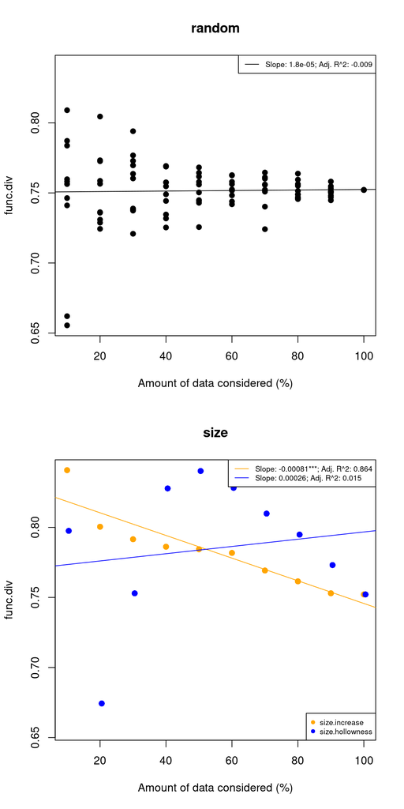

```r
plot(test.metric(grouped_space, metric = func.div, shifts = c("random", "size"), replicates = 10))
```

This metric, is more interesting as it is not directly related to the sample size and therefore more clearly decoupled from species richness. Changes in trait space sizes are linearly and inversely related to the amount of data considered (i.e. the more volume, the lower the functional diversity) which is not a problem *per se* but can be counterintuitive (hence the usefulness of testing it before interpreting it). However it is also interest to note the non-linear relationship with hollowness (blue) that can follow the same trend as the trait space size (blue) so it might be hard to disentangle either.

## The mean distance to the centroid

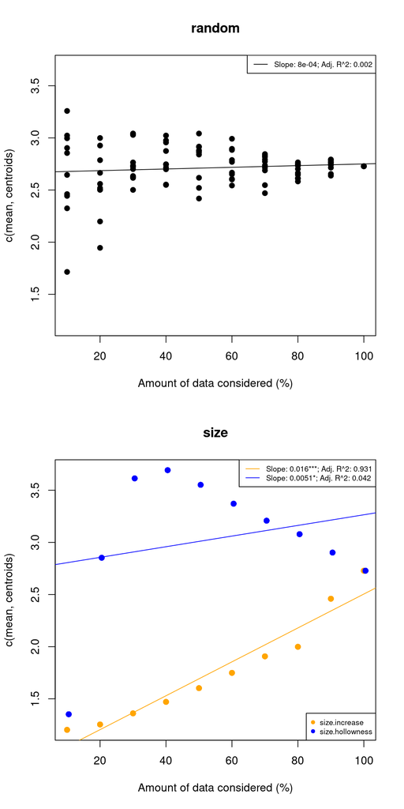

```r
plot(test.metric(grouped_space, metric = c(mean, centroids), shifts = c("random", "size"), replicates = 10))
```

Unsurprising, this metric seem to give a similar pattern as the deviation from the centroid. However, we can note here that the metric increases with size (orange) which is a good behaviour in our case. Furthermore, the hollowness (blue) seems not to be following the changes in size making it potentially easier to distinguish between both changes in the trait space.

# Results

```r
## Measuring the average distance from centroid on the rarefied subsets (to 37 elements)
rarefied_mean_cen <- dispRity(boot.matrix(grouped_space, rarefaction = 37),
                              metric =  c(mean, centroids))
```

```r
## Printing the table
summary(rarefied_mean_cen)
```

| subsets | n | obs | bs.median | 2.5% | 25% | 75% | 97.5% |
| --- | --- | --- | --- | --- | --- | --- | --- |
| extant | 37 | 2.873 | 2.835 | 2.425 | 2.688 | 2.969 | 3.232 |
| historic | 63 | 2.532 | 2.479 | 2.168 | 2.395 | 2.594 | 2.770 |
| historic | 37 | NA | 2.497 | 2.087 | 2.304 | 2.671 | 3.020 |
| all | 118 | 2.728 | 2.707 | 2.447 | 2.617 | 2.822 | 2.916 |
| all | 37 | NA | 2.697 | 2.140 | 2.519 | 2.825 | 3.035 |

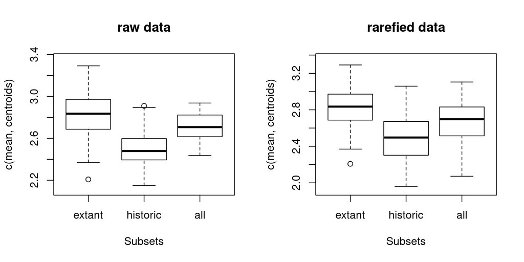

```r
par(mfrow = c(1, 2))
plot(rarefied_mean_cen, main = "raw data")
plot(rarefied_mean_cen, rarefaction = 37, main = "rarefied data")
```

> Finally note here that we only showcased some reflection about using a single metric but it is highly recommended to use more that one (Guillerme et al. (2020), Mammola et al. (2021))!

# References

Guillerme, Thomas, Mark N Puttick, Ariel E Marcy, and Vera Weisbecker. 2020. “Shifting Spaces: Which Disparity or Dissimilarity Measurement Best Summarize Occupancy in Multidimensional Spaces?” *Ecology and Evolution* 10 (14): 7261–75.

Mammola, Stefano, Carlos P Carmona, Thomas Guillerme, and Pedro Cardoso. 2021. “Concepts and Applications in Functional Diversity.” *Functional Ecology* 35 (9): 1869–85.

Matthews, Thomas J, Joseph P Wayman, Robert J Whittaker, Pedro Cardoso, Julian P Hume, Ferran Sayol, Konstantinos Proios, et al. 2023. “A Global Analysis of Avian Island Diversity–Area Relationships in the Anthropocene.” *Ecology Letters* 26 (6): 965–82.

“Preprint.” 2024.

Tobias, Joseph A, Catherine Sheard, Alex L Pigot, Adam JM Devenish, Jingyi Yang, Ferran Sayol, Montague HC Neate-Clegg, et al. 2022. “AVONET: Morphological, Ecological and Geographical Data for All Birds.” *Ecology Letters* 25 (3): 581–97.

Villéger, Sébastien, Norman WH Mason, and David Mouillot. 2008. “New Multidimensional Functional Diversity Indices for a Multifaceted Framework in Functional Ecology.” *Ecology* 89 (8): 2290–2301.